# Disinsentiveffekter

6.3.2 i Barr og ss.585-86 og 589-90 i Boeri & Ours

Mikko Moilanen

2026-03-25

## Sykepenger - kompensasjonsgrad

Brutto kompensasjonsgrad i offentlige sykepengeordninger i 2015. Gjennomsnittlig ytelse de første 26 ukene i sykepengeperioden for enslig arbeidstaker med gjennomsnittlig industrilønn. Prosent av inntekt

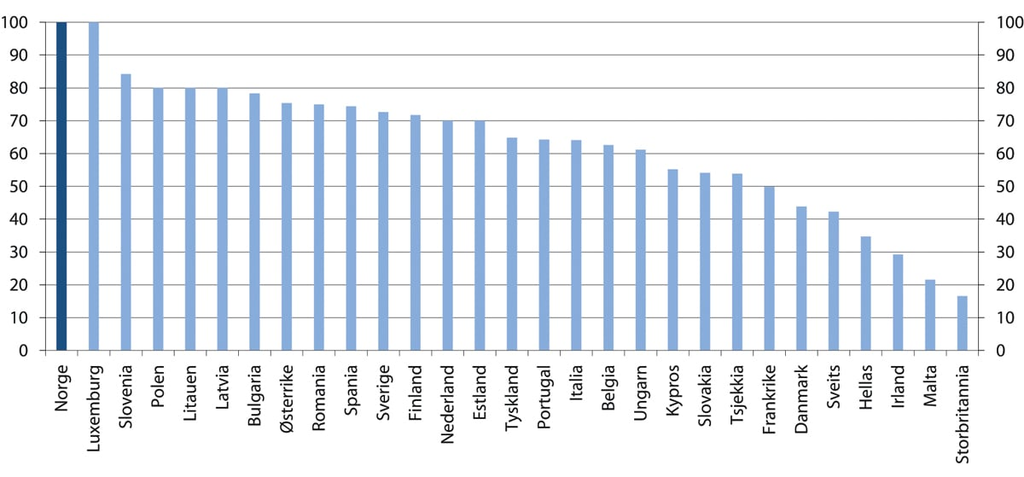

## Hvorfor er dette et viktig økonomisk spørsmål?

- Sykepenger er en forsikringsordning
  - skal beskytte inntekt når arbeidstakeren blir syk
    - en viktig velferdsgevinst
- Samtidig vil en sjenerøs ordning kunne redusere den private kostnaden ved å være borte fra arbeid
  - da kan ordningen også påvirke atferd.

Dermed oppstår et klassisk økonomisk spenningsforhold mellom:

- **forsikring og trygghet**
- **insentiver til arbeid**

## Modell for sykefravær

Vi utvider først preferansene til å inkludere helse- og belastningsparameter: $\sigma$:

$$U(c,l;\sigma)=c^{1-\sigma}l^\sigma$$

- $c$ = konsum
- $l$ = fritid / ikke-markedstid
- $\sigma \in (0,1)$

### Tolkning

- $\sigma$ er ikke et rent medisinsk mål, men en **helse- og belastningsparameter**.
  - sykdom
  - smerte
  - utmattelse
- høy $\sigma$ → arbeid oppleves mer belastende → mer fritid ønskes (restitusjon)
- lav $\sigma$ → arbeid oppleves mindre belastende → mer arbeid ønskes

$$\sigma \uparrow \Rightarrow l^* \uparrow$$

mer fritid → mer (implisitt) fravær

## Indifferenskurver på ulike nivåer av $\sigma$

[output not shown]

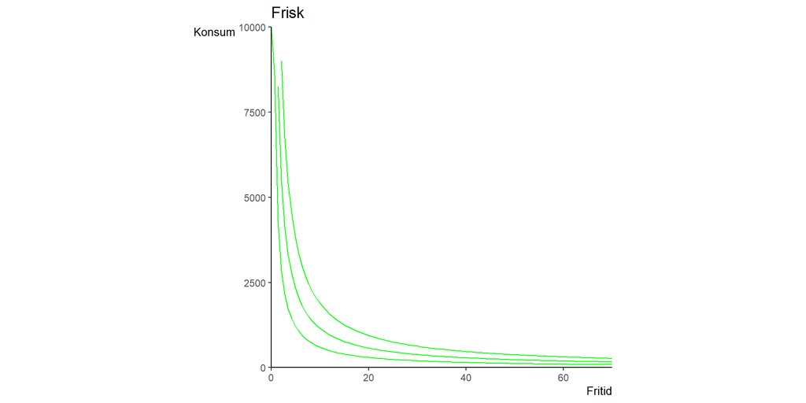

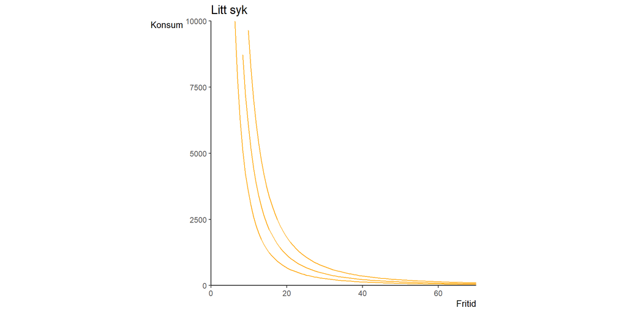

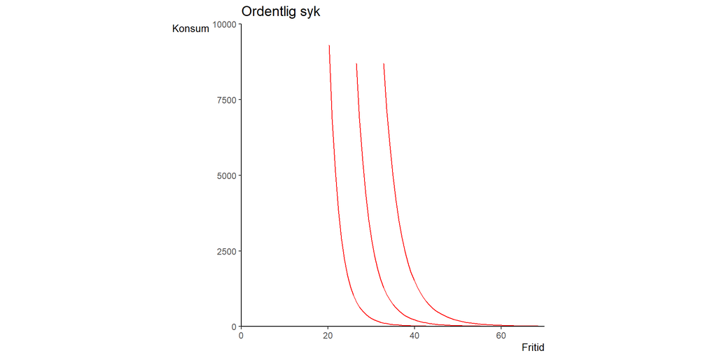

[output not shown]

## Hvordan fungerer sykepenger

### Kompensasjonsgrad

Når individet er borte fra arbeid, mottar det sykepenger.

Dette betyr at individet ikke mister hele lønna ved fravær.

### Budsjett uten sykepenger $\delta=0$

Uten sykepenger er budsjettbetingelsen:

$$c = m + w(T-l)$$
Helningen til budsjettkurven:$-w$

Det innebærer at fravær er kostbart.

### Budsjett med sykepenger

Budsjettet består av tre deler:
$$c = m + \underbrace{w h}_{\text{arbeid}} + \underbrace{\delta w (T - h)}_{\text{sykepenger}}$$
$$c = m + \delta w T + w(1-\delta)h$$
$$c = (m + wT) - w(1-\delta)l$$
Med sykepenger endres helningen til busjettkurven til til:

$$-w(1-\delta)$$
Dette er lavere enn før. Fritiden er blitt relativt billigere:
$$\delta \uparrow \Rightarrow w(1-\delta)\downarrow$$

## Tilpasning uten sykepenger

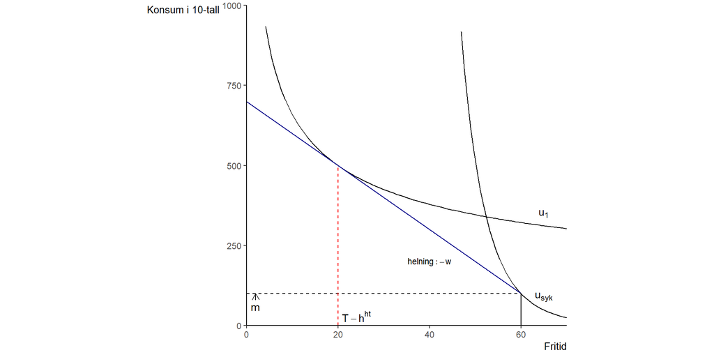

## Tilpasning med sykepenger i norsk kontekst (100 % kompensasjonsgrad)

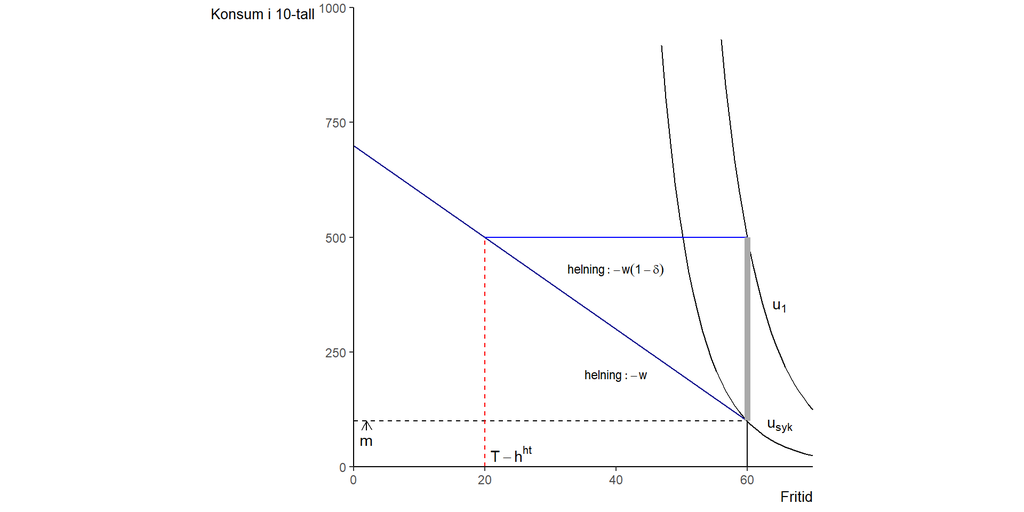

## 100 % kompensasjonsgrad: modell og virkelighet

I den enkle modellen innebærer full kompensasjon ($\delta = 1$) at den økonomiske kostnaden ved fravær forsvinner. Fritid blir da “gratis” , og individet vil alltid velge maksimal fritid og ingen arbeidstid.

Dette er imidlertid ikke det vi observerer i virkeligheten

- yrkesdeltakelsen fortsatt høy
- sykefraværet langt fra 100%

Modellen tar ikke med flere viktige mekanismer:

- Arbeid gir ikke bare inntekt, men også mening, struktur og sosial tilhørighet
- Det finnes normer og forventninger om å møte på jobb
- Fravær følges opp av arbeidsgiver, lege og NAV
- Arbeid påvirker framtidige muligheter (karriere, lønn, jobbsikkerhet)

## Modell: misbruk av sykefraværsordningen Boeri and Ours ss. 589-90

### Egenmelding

- Egenmelding gir arbeidstakere mulighet til å være borte fra jobb uten legeerklæring i en begrenset periode
- Ordningen gjelder vanligvis i opptil tre kalenderdager per fravær (ofte utvidet til 8 dager i IA-virksomheter)
- tillitsbasert ordning som reduserer administrative kostnader og behovet for legebesøk
- reduserer kontrollen med fravær, noe som kan øke rommet for tilpasning på marginen
- ordningen påvirker ikke kompensasjonsgraden direkte, men senker de praktiske og institusjonelle kostnadene ved fravær
- virker som en reduksjon i “ikke-monetære kostnader” ved fravær.

### Nå starter vi modellen

Tenk først at individet står fritt til å velge arbeidstid.

- velger den kombinasjonen av konsum og fritid som maksimerer nytten.

- den marginale verdien av fritid lik lønna
- individet har sin foretrukne arbeidstid
- individet arbeider akkurat så mye som det selv ønsker
- det er ingen grunn til å redusere arbeidstiden

### Arbeidstiden bestemmes av arbeidsgiver

I praksis bestemmes arbeidstiden av arbeidsgiver gjennom en kontrakt,la denne arbeidstiden være $h_B$

Hvis den kontraktsfestede arbeidstiden er høyere enn individets foretrukne arbeidstid, oppstår et spenn:

$$h_B > h_A$$

- individet arbeider mer enn det ønsker
- har mindre fritid enn optimalt
- oppnår lavere nytte enn i punkt A

## Shirking

Individet kan ikke fritt velge arbeidstiden.

Men det kan i praksis påvirke hvor mye det faktisk arbeider gjennom fravær.

Fravær blir dermed en måte å:

- redusere faktisk arbeidstid
- og bevege seg nærmere ønsket nivå av fritid

Dette er kjernen i modellen.

## Innføring av sykepenger

Når individet er borte fra arbeid, mottar det sykepenger.

La kompensasjonsgraden være $\delta$

Dette betyr at individet ikke mister hele lønna ved fravær.

### Budsjett med og uten sykepenger

Uten sykepenger er budsjettbetingelsen:

$$c = m + w(T-l)$$
Med sykepenger endres helningen til busjettkurven til til:

$$-w(1-\delta)$$

## Punkt D: ny tilpasning

Når fritid blir billigere, vil individet velge mer fritid.

Det nye optimum er punkt **D**:

- høyere fritid
- lavere arbeidstid
- og dermed mer fravær

Bevegelsen fra B til D er modellens kjerne:

- individet bruker fravær for å redusere arbeidstiden
- når dette blir mindre kostbart når kompensasjonsgraden øker ==> gir en systematisk økning i fravær

## Utvidelse: $\sigma$ og egenmelding

I praksis er arbeidstakere forskjellige.

Vi bruker $\sigma$ til å fange opp forskjeller i:

- helse
- belastning
- behov for restitusjon

👉 $\sigma$ er privat informasjon

Arbeidsgiver observerer ikke fullt ut hvor belastende arbeid oppleves - asymmetrisk informasjon

### Hvordan påvirker $\sigma$ punkt A?

Punkt A er individets foretrukne tilpasning.

Når $\sigma$ varierer:

- lav $\sigma$ → individet ønsker mye arbeid
- høy $\sigma$ → individet ønsker mindre arbeid

👉 $\sigma$ bestemmer hvor punkt A ligger

### Kontrakt og punkt B

Arbeidsgiveren fastsetter arbeidstid $h_B$.

Alle arbeidstakere møter samme kontrakt.

Men hvordan denne oppleves, varierer:

- lav $\sigma$ → liten forskjell mellom A og B
- høy $\sigma$ → stor forskjell mellom A og B

👉 høy $\sigma$ gir sterkere ønske om å redusere arbeid

## Hvor kommer egenmelding inn?

Egenmelding påvirker ikke preferanser.

Den påvirker hvor lett individet kan tilpasse seg.

Med egenmelding:

- lavere kontroll
- lavere praktiske kostnader ved fravær

👉 det blir enklere å være borte

### Kobling: $\sigma$ og egenmelding

Sammenhengen er:

- $\sigma$ bestemmer hvor mye individet ønsker mer fritid
- egenmelding bestemmer hvor lett det er å få det

👉 begge virker på tilpasningen fra B til D

### Hvordan påvirker $\sigma$ responsen?

Når egenmelding gjør fravær enklere:

- lav $\sigma$ → liten endring i atferd
- høy $\sigma$ → sterkere respons

👉 individer med høy opplevd belastning (=syk) vil i større grad bruke fravær

### Gråsonetilfeller

Effekten er særlig sterk når:

- individet kan arbeide
- men opplever arbeid som belastende

👉 her er $\sigma$ moderat

👉 og egenmelding gjør det lettere å velge fravær

## To typer drivkrefter

Vi kan skille mellom:

### 1. Preferanser

- hvor mye individet ønsker fritid
- påvirkes av helse og belastning ($\sigma$)

### 2. Insentiver

- hvor dyrt det er å være borte fra arbeid
- påvirkes av kompensasjonsgrad ($\delta$) og egenmelding

👉 begge er nødvendige for å forstå fravær

## Moral hazard

Moralsk hasard oppstår når:

- individet har privat informasjon om egen situasjon
- og samtidig kan påvirke sin egen atferd

I vår modell betyr dette:

- arbeidsgiver observerer ikke $\sigma$ perfekt
- individet velger selv fravær

## Hvorfor oppstår moral hazard?

Når kompensasjonsgraden øker:

$$\delta \uparrow \Rightarrow \text{lavere kostnad ved fravær}$$

Når egenmelding gjør fravær enklere:

👉 lavere kontroll og færre barrierer

Moral hazard er mest relevant når:

- individet kan arbeide
- men opplever arbeid som belastende

👉 her påvirker insentiver valget

## Det klassiske dilemmaet: forsikring vs. insentiver

Vi står overfor en avveining:

### Mer forsikring

- øker kompensasjonsgraden: høyere $\delta$
- mer trygghet
- men svakere insentiver

### Sterkere insentiver

- lavere $\delta$
- mindre fravær
- men svakere forsikring

👉 dette er kjernen i policyproblemet

👉 ingen enkel løsning

## Sluttpoeng

Sykefravær handler ikke bare om sykdom.

Det handler om:

- hvordan mennesker reagerer på insentiver
- innenfor rammene av institusjoner og kontrakter

👉 økonomisk analyse gir oss et språk for å forstå denne balansen

## Sykepenger

### Kompensasjonsgrad

- **Når sykefravær ikke innebærer noe direkte økonomisk tap for arbeidstaker, kan det bidra til høyere sykefravær**
- en stram sykepengeordning, med lav kompensasjonsgrad, kan føre til at personer som ut fra helsetilstand og arbeidsevne ikke burde jobbe, likevel går på jobb
  - For vanlige årsaker til sykefravær som muskel- og skjelettlidelser og lettere psykiske lidelser vil likevel arbeid i mange tilfeller kunne være gunstig
- en fallende kompensasjonsgrad i løpet av en sykepengeperiode vil gi arbeidstaker et økonomisk insentiv til å komme tilbake i arbeid
  - vil også gi arbeidstaker et økonomisk insentiv til å ha gradert sykmelding, siden lønnen er høyere enn sykepengene
  - Med full kompensasjon vil ikke arbeidstaker ha kortsiktige økonomiske gevinster ved gradering
- sykefravær påvirkes av andres fravær, som venner, naboer og kolleger
  - kan forsterke virkningen av økonomiske insentiver og andre faktorer som påvirker sykefraværet

## Sykefraværet og konjunkturer

- I den økonomisk litteraturen fokuseres det på tre forhold for å forklare konjunkturbevegelsene i sykefraværet: disiplineringseffekter, sammensetningseffekter og helseeffekter.

#### Disiplineringseffekt

- Arbeidsgivere vet at sykepenger kan gi arbeidstakere insentiver til å sykmelde seg uten å være (tilstrekkelig) syk
  - arbeidstakeren disiplineres av frykt for at arbeidsgiveren vil oppfatte fraværet som negativt.
- høy ledighet kan øke sannsynligheten for å miste jobben og gjøre det vanskeligere å finne nytt arbeid –> det å bli arbeidsledig vil få større konsekvenser enn når det er lav ledighet
- disiplineringseffekten virker sterkest når arbeidsledigheten er høy
- hindrer friske i å være borte fra jobben
- bidrar også til at syke går på jobb

#### Sammensetningseffekt

- oppstår ved at sysselsettingens sammensetning endres når aktivitetsnivået i økonomien endres
- Ved et høyt aktivitetsnivå vil mer marginale grupper være sysselsatt
  - Disse gruppene antas å ha mer fravær –> sykefraværet vil være høyere (lavere) i perioder med høy (lav) økonomisk aktivitet og høy (lav) sysselsetting

#### Helseeffekt

- hver enkelt arbeidstakers helse svinger med konjunkturene
  - flere kan føle seg utbrente i en høykonjunktur (lav ledighet) på grunn av at et høyt aktivitetsnivå på arbeidsplassen fører til økt fysisk og psykisk belastning

### Referanser:

- Barmby, T., Sessions, J., & Treble, J. (1994). Absenteeism, efficiency wages and shirking.*The Scandinavian Journal of Economics*, 96(4), 561-566.